# Crime Series Identification and Clustering

Michael D. Porter

2015-09-19

## Introduction to Crime Series Linkage

Statistical linkage and clustering of criminal events can be used by crime analysts to create of lists of potential suspects for an unsolved crime, identify groups of crimes that may have been committed by the same individuals or group of individuals, for offender profiling, and for predicting future events. Pairwise case linkage attempts to establish if a of crimes share a common offender. In practice, there is more interest in **crime series linkage**, which attempts to identify the *set* of crimes committed by a common offender. For example, a crime analyst may need to identify the additional crimes that are part of a crime series (crime series identification) or discover all of the crime series in a criminal incident database (crime series clustering).

**Crime series clustering** is fundamentally a clustering problem where we seek to group the crimes into clusters that correspond to a serial offender (or group of offenders). Instead of simultaneously clustering all crimes in a criminal database, **Crime series identification** is focused on identifying the additional unsolved crimes that are part of an existing crime series. Crime series identification can be useful, for example, in interrogations (R. Adderley and Musgrove 2003; Richard Adderley 2004) by providing investigators a list of additional crimes (similar to the known crimes) that a suspect may be responsible for. A crime analyst could also use crime series identification when investigating a crime series or suspected crime series to generate a list of additional crimes to jointly investigate.

The `crimelinkage` package provides several tools for crime series identification and clustering based on methods from hierarchical and model-based clustering.

## Hierarchical Based Approaches

The hierarchical-based approaches to crime series linkage are algorithmic in nature and involve creating measures of similarity between sets of crimes. The pairwise (crime-crime) similarity is a function of the Bayes factors obtained from case linkage. The group (series-series) similarity scores are based on a linkage method from hierarchical cluster analysis (e.g., single, complete, average linkage).

Because the hierarchical-based crime series clustering and crime series identification methods are based on the output from pairwise case linkage, they require having a model for estimating the log Bayes factor for a crime pair. Details for getting a Bayes factor model are given in the vignette *Statistical Methods for Crime Series Linkage*. The steps are repeated here for convenience. This analysis uses a naive Bayes to estimate the log Bayes factor.

```r
#-- Load the package and get the example crime data
library(crimelinkage)
data(crimes)               # some example crime incident data
data(offenders)            # some example crime offender data
seriesData = makeSeriesData(crimedata=crimes,offenderTable=offenders)
```

```r
#-- Make Crime Pairs for Case Linkage
set.seed(1)         # set random seed for replication
allPairs = makePairs(seriesData,thres=365,m=40)

#-- Make Evidence Variables for Case Linkage
varlist = list( spatial = c("X", "Y"),
                temporal = c("DT.FROM","DT.TO"),
                categorical = c("MO1",  "MO2", "MO3"))    # crime variables list
X = compareCrimes(allPairs,crimedata=crimes,varlist=varlist,binary=TRUE) # Evidence data
Y = ifelse(allPairs$type=='linked',1,0)      # Linkage indicator. 1=linkage, 0=unlinked


#-- Get Training Data
set.seed(3)                                        # set random seed for replication
train = sample(c(TRUE,FALSE),nrow(X),replace=TRUE,prob=c(.7,.3))  # assign pairs to training set
test = !train
D.train = data.frame(X[train,],Y=Y[train])          # training data

#-- Fit naive Bayes model and make estimateBF() function
vars = c("spatial","temporal","tod","dow","MO1","MO2","MO3")
fmla.all = as.formula(paste("Y ~ ", paste(vars, collapse= "+")))
NB = naiveBayes(fmla.all,data=D.train,weights=weight,df=10,nbins=15,partition='quantile')

estimateBF <- function(X){           # estimateBF() returns the estimated log Bayes factor
  predict(NB,newdata=X)
}
```

### Agglomerative Hierarchical Crime Series Clustering

Hierarchical clustering is an algorithmic approach to crime series cluster analysis that sequentially forms a hierarchy of cluster solutions. The agglomerative approach starts with every observation (e.g., crime incident) in its own cluster. Then it sequentially merges the two closest clusters to form a new larger cluster. This process is repeated until all observations are in the same cluster or a stopping criterion is met.

The `crimelinkage` package provides the function `crimeClust_hier()` for agglomerative hierarchical crime clustering. It uses the log Bayes factor as the pairwise similarity measure. That is, the similarity between crimes $i$ and $j$ is $S(i,j) = \log BF(i,j)$, where $BF(i,j)$ is the estimated Bayes factor for linkage. Then one of: *average*, *single*, or *complete* linkage is used for the similarity between groups.

In this example, we will cluster all of the unsolved crimes from `crimes` data and display dendrogram of results with `plot_hcc()` function.

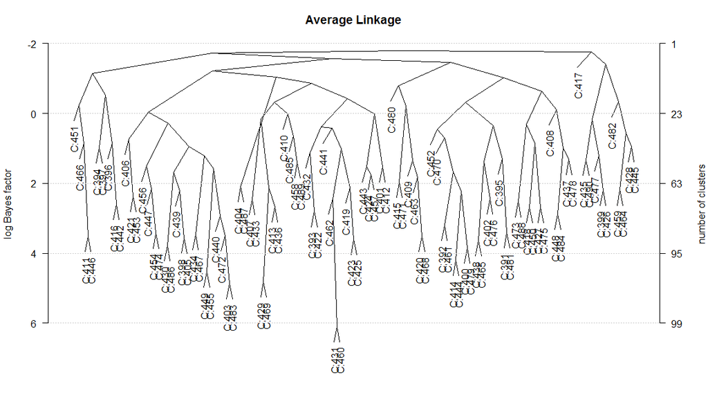

```r
#-- Get unsolved crimes
unsolved = subset(crimes, !crimeID %in% seriesData$crimeID)

#-- Run agglomerative hierarchical crime clustering
tree = crimeClust_hier(unsolved,varlist,estimateBF,linkage='average', binary=TRUE)

#-- Plot results in dendrogram using plot_hcc()
plot_hcc(tree,yticks=seq(-2,6,by=2),type="triangle",hang=.05,main="Average Linkage")
```

Examining the crimes C:431 and C:460 (which were the most similar), we can see they are close in space, around 2 weeks apart in time, and have matching values for MO1, MO2, and Mo3.

```r
#-- Examine crimes C:431 and C:460
subset(crimes,crimeID %in% c('C:431','C:460'))
```

```
#>     crimeID      X        Y MO1 MO2 MO3             DT.FROM
#> 431   C:431 7097.0 -10256.8  26   a   D 1993-10-23 22:00:00
#> 460   C:460 7195.3 -10624.8  26   a   D 1993-11-07 03:10:00
#>                   DT.TO
#> 431 1993-10-24 06:00:00
#> 460 1993-11-07 03:10:00
```

If there is a particular crime of interest, then the function `clusterPath()` will find the sequence of merges and scores for the event.

```r
#-- Find path info for crime C:429
cp = clusterPath('C:429',tree)
cp[cp$logBF>0,]                 # only return path for scores > 0
```

```
#>       logBF       crimes
#> 1 4.8226300        C:469
#> 2 2.1332281 C:413, C:436
#> 3 0.1540873 C:407, C:433
```

This shows that crime `C:429` first get grouped with crime `C:469` with a log Bayes factor of `4.82`. Then this pair gets grouped with `C:413, C:436` with an average log Bayes factor of `2.13`.